# Exercise Efficacy - a Machine Learning Prospective

Chuzhe Xiao (Gabriel)

July 24, 2016

# Synopsis

This report utilized Human Activity Recognition data to predict how well a participant is exercising. First I will load the data and do some preliminary pre-processing. Next, I will divide the training data into a training set and validation set. I will fit two different models using the training set. They are: 1, a generalized linear model, and 2, a random forest model. For the random forest model, the parameter will be chosen using the Out-of-bag (OOB) error. I will then use the validation set to choose the best performing models.

# Loading Data

The following code load the data from the web.

```r
library(caret)

setwd("C:\\Users\\Gabriel\\Dropbox\\Data Science Coursera\\Practical Machine Learning\\Project")

# download file
if(!file.exists("training.csv")){
        trainingUrl <- "https://d396qusza40orc.cloudfront.net/predmachlearn/pml-training.csv"
        download.file(trainingUrl, destfile = "./training.csv")
}
if(!file.exists("testing.csv")){
        testingUrl <- "https://d396qusza40orc.cloudfront.net/predmachlearn/pml-testing.csv"
        download.file(testingUrl, destfile = "./testing.csv")
}

## Read data
## Check if variable exist. If so, don't read data in. If not, read data
# cols_type = c("numeric","Factor",rep("numeric",3),"Factor", rep("numeric",153),"Factor")

if(!exists("training")){
        training <- read.csv("training.csv",na.strings = c("NA",""," "))
}
if(!exists("testing")){
        testing <- read.csv("testing.csv",na.strings = c("NA",""," "))
}
```

# Pre-processing

## Drop ID information

By reading the first few rows of the dataset as well as reading the names, we know that the first few columns are information about the participant as well as the time. Clearly we should exclude them from our analysis. We will apply the same method to the testing set.

```r
head(training[,1:14])
```

```
##   X user_name raw_timestamp_part_1 raw_timestamp_part_2   cvtd_timestamp
## 1 1  carlitos           1323084231               788290 05/12/2011 11:23
## 2 2  carlitos           1323084231               808298 05/12/2011 11:23
## 3 3  carlitos           1323084231               820366 05/12/2011 11:23
## 4 4  carlitos           1323084232               120339 05/12/2011 11:23
## 5 5  carlitos           1323084232               196328 05/12/2011 11:23
## 6 6  carlitos           1323084232               304277 05/12/2011 11:23
##   new_window num_window roll_belt pitch_belt yaw_belt total_accel_belt
## 1         no         11      1.41       8.07    -94.4                3
## 2         no         11      1.41       8.07    -94.4                3
## 3         no         11      1.42       8.07    -94.4                3
## 4         no         12      1.48       8.05    -94.4                3
## 5         no         12      1.48       8.07    -94.4                3
## 6         no         12      1.45       8.06    -94.4                3
##   kurtosis_roll_belt kurtosis_picth_belt kurtosis_yaw_belt
## 1               <NA>                <NA>              <NA>
## 2               <NA>                <NA>              <NA>
## 3               <NA>                <NA>              <NA>
## 4               <NA>                <NA>              <NA>
## 5               <NA>                <NA>              <NA>
## 6               <NA>                <NA>              <NA>
```

```r
training = training[,-(1:7)]
testing = testing[,-(1:7)]
```

## Drop Mostly NA Columns

In addition, we can see that there are a lot of columns with mostly NA. We also want to drop these columns.

```r
na.num = colSums(is.na(training))
# drop columns with more than 90% NA
testing = testing[,!(na.num>nrow(training)*0.9)]
training_clean = training[,!(na.num>nrow(training)*0.9)]
dim(training_clean)
```

```
## [1] 19622    53
```

## Drop mostly zero columns

We make to make sure there are no columns that are mostly zero. I used the `nearZeroVar` function in caret to check this. As it turns out, none of the columns have near zero variance

```r
cols = nearZeroVar(training_clean)
length(cols)
```

```
## [1] 0
```

## Data Partition

```r
set.seed(10)
inTrain = createDataPartition(y=training_clean$classe,p=0.8,list=FALSE)
training_set = training_clean[inTrain,]
validation_set = training_clean[-inTrain,]
```

# Analysis

## Multinomial Logistic Regression

Since the response in this case is a factor variable with more then two values, we can use [Multinomial Logistic Regression](https://en.wikipedia.org/wiki/Multinomial_logistic_regression). I used the `multinom` function in the package `nnet` and displayed the in-sample accuracy.

```r
class(training_set$classe)
```

```
## [1] "factor"
```

```r
library(nnet)
glm_mod = multinom(classe~., data = training_set)
```

### Prediction Performance

Now we can take a look at the prediction performance both in the training set and in the validation set.

```r
pred = predict(glm_mod,training_set)
err1 = sum(pred==training_set$classe)/length(pred)
pred_val = predict(glm_mod,validation_set)
err2 = sum(pred_val==validation_set$classe)/length(pred_val)
msg = paste0("In-sample accuracy: ",round(err1,4),", Validation accuracy: ",round(err2,4))
print(msg)
```

```
## [1] "In-sample accuracy: 0.6558, Validation accuracy: 0.663"
```

## Random Forest

Next, I will use a more sophisticated method, Random Forest, to make prediction. Please refer to page 588 in Elements of Statistical Learning by Hastie, Tibshirani and Friedman for a detailed discussion of random forest algorithms.

Specifically, in R, there are three important parameters. 1. `ntree`: how many trees to grow in the forest. 2, `nodesize`: how many observation in each node. Since this is a classification problem, we will choose 1. 3, `mtry`, how many predictors is chosen in each split to construct the tree. This is usually the most important parameters. Luckily, R provided the `tuneRF` function to for us to choose `mtry`.

Note that `tuneRF` use out-of-bag (OOB) error instead of cross validation error to choose parameters. This is because when building each tree, the sample is bootstrap and we will have sample that are not chosen. These are the out-of-bag sample. These are a natural choice for evaluating the performance of each tree.

First we need to tune the parameters. `tuneRF` required the input to be matrix, therefore we need to transform the data first. It is clear from the output that we should choose `mtry=7`

```r
set.seed(100)
library(randomForest)
response = training_set[,53]
predictors = as.matrix(training_set[,-53])
tuneRF(predictors,response)
```

```
## mtry = 7  OOB error = 0.57%
## Searching left ...
## mtry = 4     OOB error = 0.8%
## -0.4 0.05
## Searching right ...
## mtry = 14    OOB error = 0.65%
## -0.1333333 0.05
```

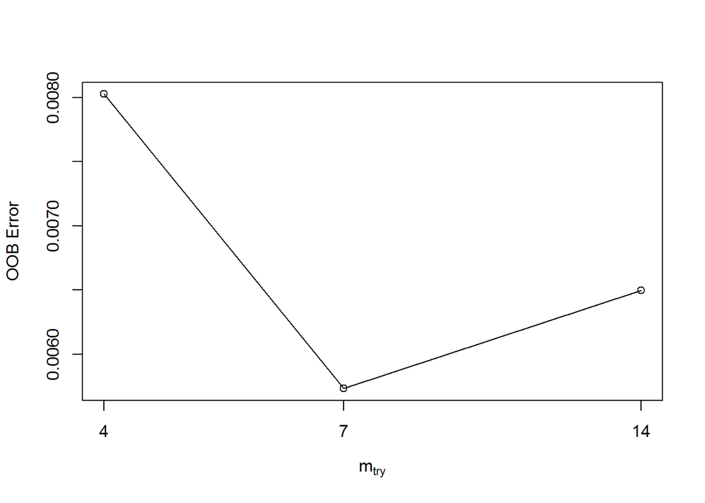

```
##        mtry    OOBError
## 4.OOB     4 0.008025989
## 7.OOB     7 0.005732849
## 14.OOB   14 0.006497229
```

Now we can fit a random forest model. I choose `ntree=200` to speed up the running time. I also plotted the error as tree size increase. It seems like 200 is more than enough.

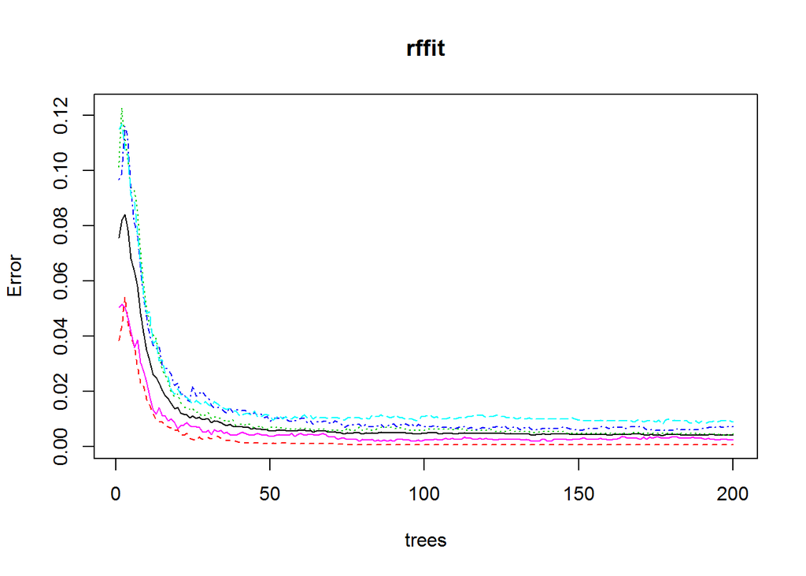

```r
rffit = randomForest(classe~., data=training_set,mtry=7,nodesize=1,ntree=200)
plot(rffit)
```

### Prediction Performance

Now we can take a look at the prediction performance both in the training set and in the validation set.

```r
pred = predict(rffit,training_set)
err1 = sum(pred==training_set$classe)/length(pred)
pred_val = predict(rffit,validation_set)
err2 = sum(pred_val==validation_set$classe)/length(pred_val)
msg = paste0("In-sample accuracy: ",round(err1,4),", Validation accuracy: ",round(err2,4))
print(msg)
```

```
## [1] "In-sample accuracy: 1, Validation accuracy: 0.9982"
```

# Conclusion

## Prediction in test set

We can also make a prediction for the test test.

```r
test_pred = predict(rffit,testing)
test_pred
```

```
##  1  2  3  4  5  6  7  8  9 10 11 12 13 14 15 16 17 18 19 20
##  B  A  B  A  A  E  D  B  A  A  B  C  B  A  E  E  A  B  B  B
## Levels: A B C D E
```